# 1MP3 Midterm 2 Review

14 November 2019

## reading files

- `f = open(filename, "r")`, `f.close()`
- `f.read()` reads the *entire file* as a string
- `f.read(n)` reads the next `n` characters  
  (closing and reopening starts from the beginning again)
- reading past the end of a file returns "" (like slicing)
- `for line in f:` reads a line at a time
- `f.readline()` reads one line

## processing strings

- strings read from files include `\n` (newline)
- `s.strip()` gets rid of newlines and whitespace
- `s.split()` splits strings into a list (by spaces, by default)
- `s.lower()`, `s.upper()` to convert to lower/uppercase
- `s.replace(val1,val2)` replaces `val1` with `val2` in `s` (e.g. cleaning punctuation)

## sets

- collections of objects (any type)
- **unordered** (can’t index or slice), **mutable**
- **iterable**: can use `for i in S:`, `len()`, `in`
- define a new set with `{"a","b","c"}`; empty set is `set()`, **NOT** `{}` (which is a `dict`) …
- … or convert from a list/tuple/etc. `set(["a","b","c"])`
- add new elements with `S.add("d")`. remove with `remove()`
- **duplicated elements are silently removed**
- `.intersection`, `.union`
- `.issubset`, comparison operators (`<`, `<=` etc.)

## dictionaries

- collections of keys and values
- unordered, mutable, iterable
- keys act like a set
- setup via `{"A":1, "B":2}` or `dict([["A",1],["B",2]])` or `dict(A=1,B=2)`
- keys can be any non-mutable type (int, float, tuple)
- values can be anything
- `for i in d:` iterates over keys; `in` searches in keys
- add **or replace** a key/value pair: `d[k] = v`
- delete a key/value pair: `del d[k]`
- `d[k]` extracts the value associated with `k`
- `d.keys()` returns keys (set-like); `d.values()` returns values (list-like); .`items()` returns a list-like object holding `(key,value)` tuples
- processing a dictionary (with `for k in d:` or `for k, v in d.items():`)
- dictionary inversion

## random number

- `random` and `numpy.random` modules (similar)
- `random.seed(102)`: initialize random-number generator (RNG) to a known point (for reproducibility)
- `random.randrange()`: pick one value from a range
- `random.choice()`: pick one value from a list/tuple
- `random.random()`: random float uniformly from $[0,1)$
- `random.uniform(a,b)`: random float uniformly from $[a,b)$

## numpy arrays

- `np.array()`: from list, tuple, nested lists or tuples
- `dtype=` argument specifies data type (“float”, “int32”, “int8”, “uint8” etc.)
- `a.shape` returns a tuple giving dimensions
- `len(a)` gives length of dimension 0
- also create arrays with `np.ones()`, `np.zeros()`, `np.arange()`
- `shape=` argument: tuple specifying dimensions; `np.ones(4)` is the same as `np.ones((4,))`; `np.ones((4,4))` returns a 4 $\times$ 4 matrix
- `a.fill(v)` fills array `a` with value `v`

## slicing and indexing arrays

- indexing: `a[i]` or `a[i,j]` or `a[i,j,k]` (depending on dimensions)
- slicing: `a[m:n]` or `a[m:n,:]` or …; `:` by itself means “all rows/columns/slices”
- `a.copy()` to make a copy

## reshaping arrays

- `a.reshape((r,c))` specifies number of columns (total number of elements must match)
- `a[:,np.newaxis]` adds a new length-1 dimension
- `a.flatten()` converts to 1-D

## matrices

- `np.identity`, `np.eye` for identity matrices
- **not covered**: linear algebra (`np.linalg.det`, `np.linalg.dot`, `np.linalg.eig`, `np.linalg.inv`)

## operations

- all arithmetic (`+`, `-`, `*`, etc.) operates **elementwise** on arrays
- … or on array + scalar
- also numpy functions `np.sin()`, `np.cos()`, etc.
- `np.sum()`, `np.mean()`, `np.prod()` etc. operate on *all elements* by default
- `axis=i` argument **collapses dimension i** (e.g. `np.mean(a,axis=0)` on a 2D array computes mean of each column, collapsing rows)

## logical operations

- comparisons (`>`, `==` etc.) work elementwise, producing a `bool` array
- `np.logical_and()`, `np.logical_or()`, `np.logical_not()`
- `a[b]` selects the elements of `a` for which bool array `b` is `True`
- e.g. `a[a>0]` selects positive elements

## numerics

This appears on the test:

> Some helpful numbers: $2^7=128$; $2^8=256$; $2^{2^{10}} \approx 10^{308}$; $2^{-53} \approx 10^{-16}$.

Maybe useful for thinking about integers:

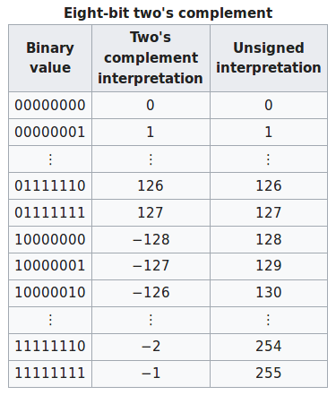